# Pneumonia Detection with deep CNN model

Machine learning and Deep learning have a huge implementation in healthcare but applying them in healthcare isn't that simple. If we are able to apply machine learning in healthcare field very well, it will largely benefit the world and the way we living.

In this project, we will see how deep learning helps classify x-ray images for helping doctors detecting Pneumonia patients. Pneumonia is a very common disease, which can be caused by a variety of organisms including bacteria, viruses and fungi. The recently pandemic disease COVID-19 showed the similar pattern. And before the production of virus detection kit, doctors have to reply on the X-ray picture to determine whether the patients suffered from COVID-19. Thus, it is very helpful to develop a robust deep learning model.

[figure not shown]

### Download data from Kaggle

This dataset is provided by Kaggle ([Link to Data](https://https://www.kaggle.com/paultimothymooney/chest-xray-pneumonia)). By means of Google colab, I am able to use the free GPU to run the model in a faster speed. But the first step is to download the data from kaggle.

```python
#from google.colab import drive
#drive.mount('/content/gdrive')
```

```python
#import os
#os.environ['KAGGLE_CONFIG_DIR'] = "/content/gdrive/My Drive/kaggle"
# /content/gdrive/My Drive/kaggle is the path where kaggle.json is present in the Google Drive
```

```python
#changing the working directory
#%cd /content/gdrive/My Drive/kaggle
```

```
/content/gdrive/My Drive/kaggle
```

```python
# download the data from kaggle
#!kaggle datasets download -d paultimothymooney/chest-xray-pneumonia
```

```
Downloading chest-xray-pneumonia.zip to /content/gdrive/My Drive/kaggle
100% 2.29G/2.29G [00:49<00:00, 66.1MB/s]
```

```python
#unzipping the zip files and deleting the zip files
#!unzip \*.zip  && rm *.zip
```

### Start from here

Now, I have the dataset/image folders on my google drive. In the future running of this project, I can start from here.

```python
# start from here
from google.colab import drive
drive.mount('/content/gdrive')
import os
os.environ['KAGGLE_CONFIG_DIR'] = "/content/gdrive/My Drive/kaggle"
%cd /content/gdrive/My Drive/kaggle
```

```
Go to this URL in a browser: https://accounts.google.com/o/oauth2/auth?client_id=947318989803-6bn6qk8qdgf4n4g3pfee6491hc0brc4i.apps.googleusercontent.com&redirect_uri=urn%3aietf%3awg%3aoauth%3a2.0%3aoob&response_type=code&scope=email%20https%3a%2f%2fwww.googleapis.com%2fauth%2fdocs.test%20https%3a%2…

Enter your authorization code:
··········
/content/gdrive/My Drive/kaggle
```

```python
os.listdir('/content/gdrive/My Drive/kaggle/chest_xray')
```

```
['__MACOSX', 'chest_xray', 'test', 'train', 'val']
```

👆 'test', 'train', 'val' are folders that contains the images.

```python
import numpy as np
import glob
import pandas as pd
import tensorflow as tf
import matplotlib.pyplot as plt
import seaborn as sns
from sklearn.model_selection import train_test_split
from tensorflow import keras
from keras.models import Sequential
from keras.layers import Dense, Dropout, Conv2D, MaxPooling2D, Flatten
from keras.optimizers import RMSprop
from keras.utils import plot_model
from keras.preprocessing.image import ImageDataGenerator, load_img
%matplotlib inline

import warnings
warnings.filterwarnings("ignore")
```

```python
# get the train and test data path
train_dir = '/content/gdrive/My Drive/kaggle/chest_xray/train/'
test_dir = '/content/gdrive/My Drive/kaggle/chest_xray/test/'
val_dir = '/content/gdrive/My Drive/kaggle/chest_xray/val/'
os.listdir(train_dir)
```

```
['NORMAL', 'PNEUMONIA']
```

👆 In each folder, there are two class folders that contain normal images and pneumonia images respectively.

```python
# get path to images
train_normal = train_dir +'NORMAL/'
train_pneu = train_dir +'PNEUMONIA/'
test_normal = test_dir +'NORMAL/'
test_pneu = test_dir +'PNEUMONIA/'
val_normal = val_dir +'NORMAL/'
val_pneu = val_dir +'PNEUMONIA/'
```

```python
# let's take a look of all the images in each folder.
print(len(os.listdir(train_normal)))
print(len(os.listdir(train_pneu)))
print(len(os.listdir(test_normal)))
print(len(os.listdir(test_pneu)))
print(len(os.listdir(val_normal)))
print(len(os.listdir(val_pneu)))
```

```
1145
3236
234
390
204
647
```

### Visualizations

```python
# Get the list of all the images
from pathlib import Path
normal_cases = Path(train_normal).glob('*.jpeg')
pneumonia_cases = Path(train_pneu).glob('*.jpeg')
```

```python
train_img = []
for img in normal_cases:
  train_img.append((img,0))

for img in pneumonia_cases:
  train_img.append((img,1))
```

```python
# Get a pandas dataframe from the data we have in our list
train_data = pd.DataFrame(train_img, columns=['image', 'label'],index=None)

# select 80% of the train data to train the model
train_data = train_data.sample(frac=1.).reset_index(drop=True)
```

```
1    3236
0    1145
Name: label, dtype: int64
```

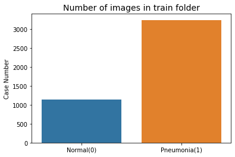

```python
count_n = train_data['label'].value_counts()
print(count_n)

plt.figure(figsize=(6,4))
sns.barplot(x=count_n.index, y =count_n.values)
plt.title('Number of images in train folder', fontsize = 14)
plt.ylabel('Case Number')
plt.xticks(range(len(count_n.index)), ['Normal(0)', 'Pneumonia(1)'])
plt.show()
```

#### Let's see some x-ray images

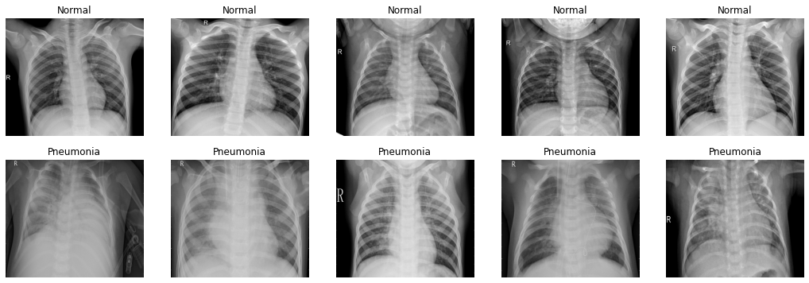

```python
# get some samples for both classes
normal_samp = (train_data[train_data['label']==0]['image'].iloc[0:5]).tolist()
pneu_samp = (train_data[train_data['label']==1]['image'].iloc[0:5]).tolist()

samples = normal_samp + pneu_samp
f,ax = plt.subplots(2, 5, figsize = (18, 6))
for i in range(10):
  img = load_img(samples[i])
  ax[i//5, i%5].imshow(img, cmap = 'gray')
  if i<5:
    ax[i//5, i%5].set_title('Normal')
  else:
    ax[i//5, i%5].set_title('Pneumonia')
  ax[i//5, i%5].axis('off')
  ax[i//5, i%5].set_aspect('auto')
plt.show()
```

In fact, there are only 16 images in the original validation folder, which is not enough for our training process. I used the following code to move 20% of images in training image folders to validation folders. Therefore, we can see a sufficient number of images in both datasets.

```python
# select 80% of the train data to train the model
#train_data = train_data.sample(frac=.8).reset_index(drop=True)

#  20% as the validation dataset
#val_data = train_data.sample(frac=.2).reset_index(drop=True)
```

```python
# move the selected val_data to val_data folder
#import shutil

#destination1 = val_normal

#for file in val_data[val_data['label']==0]['image']:
#	new_path = shutil.move(str(file), destination1)

#destination2 = val_pneu

#for file in val_data[val_data['label']==1]['image']:
#	shutil.move(str(file), destination2)
```

```python
normal_cases = Path(val_normal).glob('*.jpeg')
pneumonia_cases = Path(val_pneu).glob('*.jpeg')

val_img = []
for img in normal_cases:
  val_img.append((img,0))

for img in pneumonia_cases:
  val_img.append((img,1))

# Get a pandas dataframe from the data we have in our list
val_data = pd.DataFrame(val_img, columns=['image', 'label'],index=None)

val_data = val_data.sample(frac=1.).reset_index(drop=True)

val_data.head()
```

|  | image | label |
| --- | --- | --- |
| 0 | /content/gdrive/My Drive/kaggle/chest_xray/val... | 0 |
| 1 | /content/gdrive/My Drive/kaggle/chest_xray/val... | 1 |
| 2 | /content/gdrive/My Drive/kaggle/chest_xray/val... | 1 |
| 3 | /content/gdrive/My Drive/kaggle/chest_xray/val... | 1 |
| 4 | /content/gdrive/My Drive/kaggle/chest_xray/val... | 0 |

```
1    647
0    204
Name: label, dtype: int64
```

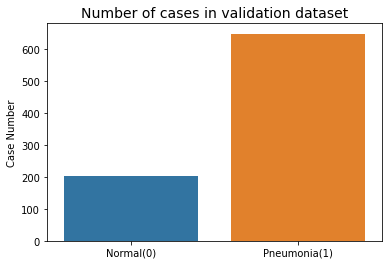

```python
count_n =  val_data['label'].value_counts()
print(count_n)

plt.figure(figsize=(6,4))
sns.barplot(x=count_n.index, y =count_n.values)
plt.title('Number of cases in validation dataset', fontsize = 14)
plt.ylabel('Case Number')
plt.xticks(range(len(count_n.index)), ['Normal(0)', 'Pneumonia(1)'])
plt.show()
```

```python
print(len(os.listdir(train_normal)))
print(len(os.listdir(train_pneu)))
print(len(os.listdir(val_normal)))
print(len(os.listdir(val_pneu)))
```

```
1145
3236
204
647
```

```python
# remove the image in train folder that have been transferred to val folder
#for img in os.listdir(train_normal):
#  if img in val_data[val_data['label']==0]['image']:
#    os.remove(img)
#for img in os.listdir(train_pneu):
#  if img in val_data[val_data['label']==1]['image']:
#    os.remove(img)

#len(os.listdir(train_pneu))
```

### Data augmentation

In order to avoid overfitting problem, I need to expand artifically the dataset and make it even larger. Here I didn't add rotation because it is medical image, the orientation should always be vertical. I make the following changes:

```python
data_gen = ImageDataGenerator(rescale = 1/255,
                              zoom_range = 0.2,
                              width_shift_range = 0.1,
                              height_shift_range = 0.1,
                              )
test_gen = ImageDataGenerator(rescale = 1/255)


train_gen_data = data_gen.flow_from_directory(train_dir,
                                                target_size =(224, 224),
                                                batch_size = 64,
                                                color_mode='rgb',
                                                class_mode = "categorical")

val_gen_data = data_gen.flow_from_directory(val_dir,
                                              target_size =(224, 224),
                                              batch_size = 64,
                                              color_mode='rgb',
                                              class_mode = "categorical")


test_gen_data = test_gen.flow_from_directory(test_dir,
                                              target_size =(128, 128),
                                              batch_size = 64,
                                              color_mode='rgb',
                                              class_mode = "categorical")
```

```
Found 4381 images belonging to 2 classes.
Found 851 images belonging to 2 classes.
Found 624 images belonging to 2 classes.
```

### Modeling

#### The First CNN model

```python
model = Sequential()

input_shape = (128, 128, 1)

model.add(Conv2D(16, kernel_size=(3, 3),
                 activation='relu',
                 input_shape=input_shape))
# 32 3x3 kernels
model.add(Conv2D(32, (3, 3), activation='relu'))

# Reduce by taking the max of each 2x2 block
model.add(MaxPooling2D(pool_size=(2, 2)))

# Dropout to avoid overfitting
model.add(Dropout(0.20))

# Flatten the results to one dimension for passing into our final layer
model.add(Flatten())

# A hidden layer to learn with
model.add(Dense(16, activation='relu'))

# Final categorization with 0 for Normal and 1 for Pneumonia
model.add(Dense(1, activation='sigmoid'))

model.summary()
```

```
Model: "sequential_2"
_________________________________________________________________
Layer (type)                 Output Shape              Param #
=================================================================
conv2d_3 (Conv2D)            (None, 126, 126, 16)      160
_________________________________________________________________
conv2d_4 (Conv2D)            (None, 124, 124, 32)      4640
_________________________________________________________________
max_pooling2d_2 (MaxPooling2 (None, 62, 62, 32)        0
_________________________________________________________________
dropout_2 (Dropout)          (None, 62, 62, 32)        0
_________________________________________________________________
flatten_2 (Flatten)          (None, 123008)            0
_________________________________________________________________
dense_3 (Dense)              (None, 16)                1968144
_________________________________________________________________
dense_4 (Dense)              (None, 1)                 17
=================================================================
Total params: 1,972,961
Trainable params: 1,972,961
Non-trainable params: 0
_________________________________________________________________
```

```python
model.compile(loss='binary_crossentropy',
              optimizer='adam',
              metrics=['accuracy'])
```

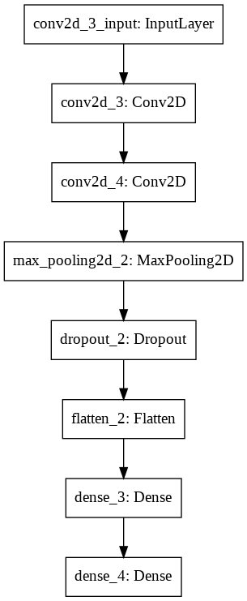

```python
plot_model(model)
```

Train the model

```python
cnn_model = model.fit_generator(train_gen_data,
            validation_data = val_gen_data,
            epochs = 20,
            verbose = 1)
```

```
<function matplotlib.pyplot.show>
```

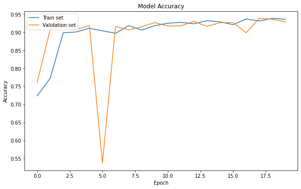

```python
# accuracy
plt.figure(figsize = (10,6))
plt.plot(cnn_model.history['accuracy'])
plt.plot(cnn_model.history['val_accuracy'])
plt.title('Model Accuracy')
plt.ylabel("Accuracy")
plt.xlabel('Epoch')
plt.legend(['Train set', 'Validation set'], loc='upper left')
plt.show
```

```
<function matplotlib.pyplot.show>
```

[figure not shown]

```python
# loss
plt.figure(figsize = (10,6))
plt.plot(cnn_model.history['loss'])
plt.plot(cnn_model.history['val_loss'])
plt.title('Model Loss')
plt.ylabel("Accuracy")
plt.xlabel('Epoch')
plt.legend(['Train set', 'Validation set'], loc='upper left')
plt.show
```

Classify the testset

```python
test_loss, test_score = model.evaluate(test_gen_data)
print("Loss on test set: ", test_loss)
print("Accuracy on test set: ", test_score)
```

```
Loss on test set:  0.28363773226737976
Accuracy on test set:  0.8878205418586731
```

The loss on the testset is 28.36% and the accuracy is 88.7%.

```python
cnn_prob = model.predict_generator(test_gen_data)
```

```python
class_b = []
for i in cnn_prob:
  if i[1]>0.5:
    class_b.append(1)
  else:
    class_b.append(0)
```

```python
confusion_cnn = confusion_matrix(test_gen_data.classes, class_b)
confusion_cnn
```

```
array([[  0, 234],
       [  0, 390]])
```

Let's save the model!

```python
model.save_weights("model1.h5")
```

Now, or in the future, we can directly load the model to classify new test images

```python
# model.load_weights("/content/gdrive/My Drive/kaggle/model.h5")
```

#### VGG16 transfer learning

VGG16 is a convolutional neural network model proposed by K. Simonyan and A. Zisserman from the University of Oxford in the paper “Very Deep Convolutional Networks for Large-Scale Image Recognition”. The model achieves 92.7% top-5 test accuracy in ImageNet, which is a dataset of over 14 million images belonging to 1000 classes. It was one of the famous model submitted to ILSVRC-2014.

```python
from keras.applications.vgg16 import VGG16
from keras.applications.vgg16 import preprocess_input
from sklearn.metrics import classification_report, confusion_matrix
from tensorflow.keras.callbacks import EarlyStopping
from keras.models import Model
```

```python
def Vgg_16_model (n_row, n_column, n_channel, num_classes= None):
  vgg = VGG16(input_shape= [n_row,n_column, n_channel], weights='imagenet', include_top=False)
  for layer in vgg.layers:
    layer.trainable = False
  flatten1 = Flatten()(vgg.output)
  dense1 = Dense(256, activation="relu")(flatten1)
  dropout1 = Dropout(0.5)(dense1)
  prediction = Dense(num_classes, activation="softmax")(dropout1)

  model = Model(inputs=vgg.input, outputs=prediction)
  print(model.summary)
  model.compile(optimizer='adam', loss='categorical_crossentropy', metrics=['accuracy'])
  return model
```

```python
n_row = 224
n_column = 224
n_channel = 3
num_classes = 2
```

```python
early_stop = EarlyStopping(monitor = 'val_loss', patience = 2)
vgg_model = Vgg_16_model (n_row, n_column, n_channel, num_classes)
```

```
<bound method Network.summary of <keras.engine.training.Model object at 0x7f3f1e4da668>>
```

```python
history = vgg_model.fit_generator(train_gen_data,
                                  validation_data=val_gen_data,
                                  epochs=20,
                                  callbacks= [early_stop])
```

```
<function matplotlib.pyplot.show>
```

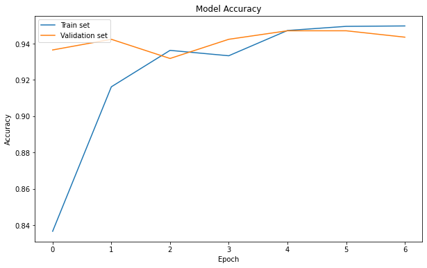

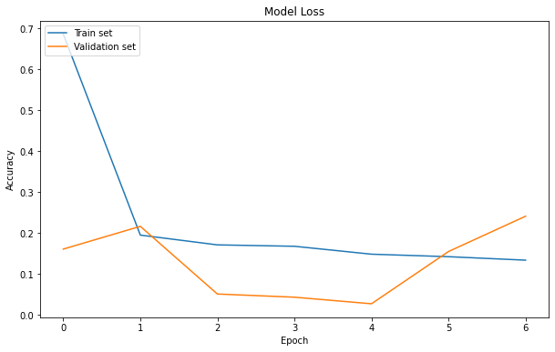

```python
# accuracy
plt.figure(figsize = (10,6))
plt.plot(history.history['accuracy'])
plt.plot(history.history['val_accuracy'])
plt.title('Model Accuracy')
plt.ylabel("Accuracy")
plt.xlabel('Epoch')
plt.legend(['Train set', 'Validation set'], loc='upper left')
plt.show

# loss
plt.figure(figsize = (10,6))
plt.plot(history.history['loss'])
plt.plot(history.history['val_loss'])
plt.title('Model Loss')
plt.ylabel("Accuracy")
plt.xlabel('Epoch')
plt.legend(['Train set', 'Validation set'], loc='upper left')
plt.show
```

```python
test_loss, test_score = vgg_model.evaluate_generator(test_gen_data)
```

```python
print("Loss on test set: ", test_loss)
print("Accuracy on test set: ", test_score*100)
```

```
Loss on test set:  0.5344783663749695
Accuracy on test set:  90.06410241127014
```

```python
pred_prob = vgg_model.predict_generator(test_gen_data)
```

```python
pred_class = []
for i in pred_prob:
  if i[1]>0.5:
    pred_class.append(1)
  else:
    pred_class.append(0)
```

```python
confusion_m = confusion_matrix(test_gen_data.classes, pred_class)
confusion_m
```

```
array([[ 65, 169],
       [115, 275]])
```

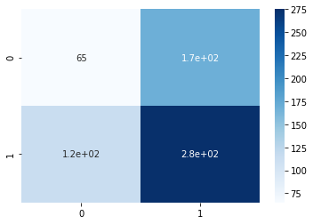

```python
sns.heatmap(confusion_m, annot=True, cmap = 'Blues')
```

### Summary

In this project, I found that Augmentation helps a lot in reducing overfitting and improve model performance. Because I have trained the first model when there is no augmentation added, the accuracy was 70%. After image augmentation, the accuracy improved from 70% to 88%.

The modified transfering VGG16 CNN model improved the accuracy by 2% and it saved a lot of time comparing building the first model from raw.

The final accuracy in the project reached 90%, I think there is room to further improve the accuracy. However, by looking at the confusion matrix, the error is still large. Thus, I think machine learning can only be working as a reference when doctor making decisions.

The similar modeling method is also applicable to the diagnosis of COVID-19. There are people who kindly uploaded the COVID-19 x-ray image data [link to the data source](https://www.kaggle.com/praveengovi/coronahack-chest-xraydataset)